# Individfaktorer, Stockholmsenkäten

Magnus Johansson, RISE

2022-02-21

# 1 Individfaktorer

Vi kommer att analysera

- dimensionalitet och residualkorrelationer
- hur svarskategorierna fungerar och ev. behov av förändringar
- hur väl frågorna fungerar i termer av ”item fit” till Rasch-modellen
- hur frågornas ”svårighetsgrad” matchar mot respondenternas egenskaper
- reliabilitet (över hela indexet, ”test information function”)
- invarians – att frågorna fungerar lika mellan kön och mättillfällen (och ev. mellan åk 9 och åk 2 på gymnasiet? ej specat i avtalet, men rimligen relevant)
- omvandling av summerade rådata till intervalldata med mätosäkerheter på individnivå

Item/frågor har etiketter f66a-f66u i datafilen, och motsvaras av fråga 67 i PDF-filen med frågor.

“Hur väl stämmer följande påståenden in på dig som person?” följs av de ingående frågorna, alla med samma svarskategorier:

- ‘Stämmer mycket dåligt’
- ‘Stämmer ganska dåligt’
- ‘Stämmer ganska bra’
- ‘Stämmer mycket bra’

Items f66h, m, p och u är reverserade.

Höga poäng innebär genomgående hög risk.

## 1.1 Deskriptiv statistik

Svarsfördelningen för varje enskild fråga

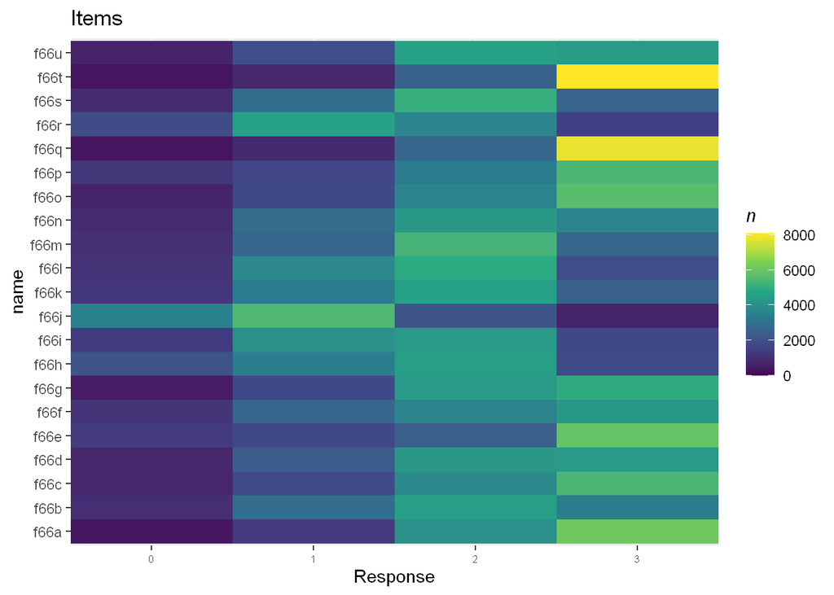

## 1.2 Frågorna som ingår i Individfaktorer

| itemnr | items |
| --- | --- |
| f66a | Jag gör tvärt emot vad människor säger åt mig att göra, bara för att göra dem arga. |
| f66b | Jag gillar att göra spännande och farliga saker, även om det är förbjudet. |
| f66c | Jag tål inte att bli provocerad – då kan jag slå till någon. |
| f66d | Jag ljuger för att få fördelar eller slippa göra jobbiga saker. |
| f66e | Om jag blir arg på någon drar jag mig inte för att skada honom/henne. |
| f66f | Jag är ofta ute på natten tillsammans med kamrater. |
| f66g | Jag struntar i regler som hindrar mig från att göra det jag vill göra. |
| f66h | Jag tycker det är roligt att lösa svåra problem och uppgifter. |
| f66i | Jag ser mig själv som en ganska impulsiv person. |
| f66j | Jag vill gärna vara där det händer spännande saker. |
| f66k | Jag kan få andra att tro på nästan vad som helst. |
| f66l | Jag blir ofta osäker när jag ställs inför nya uppgifter. |
| f66m | Jag tänker oftast efter innan jag talar eller gör saker. |
| f66n | Jag gör dumma saker även om de är lite farliga. |
| f66o | Jag vill gärna se hur långt jag kan gå innan folk får nog. |
| f66p | Det är fel att fuska i skolan. |
| f66q | Jag tycker att det är OK att ta något utan att fråga, om man inte blir upptäckt. |
| f66r | Det händer att jag gör saker utan att tänka mig för. |
| f66s | Om jag ställs inför en svår uppgift så väljer jag att göra något annat. |
| f66t | Den som gör mig arg ger jag mig på – även om han/hon inte slagit mig först. |
| f66u | Det är viktigt att vara ärlig mot föräldrarna, även om de blir arga. |

Vi har totalt 12540 personer i vårt sampel. (“NA” i tabeller = “svar saknas”)

|  | Antal |
| --- | --- |
| Flickor | 6271 |
| Pojkar | 5731 |
| Ej svar | 538 |

```
##
## Gy 2 Åk 9
## 6971 5569
```

|  | ARSKURS |  |  |
| --- | --- | --- | --- |
| Kön | Gy 2 | Åk 9 | Total |
| Flicka | 58.4% (3661) | 41.6% (2610) | 100.0% (6271) |
| Pojke | 53.1% (3041) | 46.9% (2690) | 100.0% (5731) |
| NA | 50.0% (269) | 50.0% (269) | 100.0% (538) |

# 2 Dimensionalitet och residualkorrelationer

För att köra Rasch-analys behöver vi i detta skede ta bort individer med missing data, vilket innebär att vårt sampel minskar till 9016, vilket innebär att 3524 personer har tagits bort

Först gör vi en PCA, principalkomponentanalys, på residualerna från Rasch-modellen.

Eigenvalues för residualer bör vara under 2.0 och de fem första är 2.57, 1.87, 1.64, 1.42, 1.3.

Det innebär att vi har problem med multidimensionalitet. För att undersöka vilka items som skapar problem tar vi fram en tabell som visar hur väl items passar modellen. Det huvudsakliga måttet är Rasch item fit residual MSQ, som bör ligga mellan 0.7 och 1.3. Som komplement har vi coefH från Mokken Scaling model, som bör vara över 0.3. Aisp visar med siffran 0 vilka items som fungerar undermåligt, och siffror över 1 innebär att items hänger samman i en separat dimension.

|  | aisp | coefH | OutfitMSQ | InfitMSQ |
| --- | --- | --- | --- | --- |
| f66a | 1 | 0.310 | 0.754 | 0.786 |
| f66b | 1 | 0.349 | 0.694 | 0.706 |
| f66c | 1 | 0.281 | 0.848 | 0.851 |
| f66d | 1 | 0.303 | 0.787 | 0.808 |
| f66e | 0 | 0.172 | 1.512 | 1.169 |
| f66f | 1 | 0.239 | 0.972 | 0.967 |
| f66g | 1 | 0.346 | 0.692 | 0.718 |
| f66h | 0 | 0.058 | 1.490 | 1.380 |
| f66i | 1 | 0.218 | 1.005 | 0.996 |
| f66j | 1 | 0.247 | 0.947 | 0.950 |
| f66k | 1 | 0.214 | 1.036 | 1.014 |
| f66l | 2 | 0.109 | 1.241 | 1.212 |
| f66m | 0 | 0.113 | 1.296 | 1.211 |
| f66n | 1 | 0.336 | 0.724 | 0.736 |
| f66o | 1 | 0.315 | 0.741 | 0.780 |
| f66p | 3 | 0.182 | 1.247 | 1.110 |
| f66q | 1 | 0.259 | 0.823 | 0.881 |
| f66r | 1 | 0.258 | 0.928 | 0.933 |
| f66s | 2 | 0.227 | 0.967 | 0.968 |
| f66t | 1 | 0.278 | 0.776 | 0.839 |
| f66u | 3 | 0.117 | 1.268 | 1.207 |

Utifrån rödmarkerade värden kan vi se att f66e och h har för hög OutfitMSQ. De indikeras också med siffran 0 i aisp-kolumnen, vilket även f66m gör, men vi låter den vara kvar för tillfället eftersom MSQ är acceptabel.

| itemnr | items |
| --- | --- |
| f66a | Jag gör tvärt emot vad människor säger åt mig att göra, bara för att göra dem arga. |
| f66b | Jag gillar att göra spännande och farliga saker, även om det är förbjudet. |
| f66c | Jag tål inte att bli provocerad – då kan jag slå till någon. |
| f66d | Jag ljuger för att få fördelar eller slippa göra jobbiga saker. |
| f66e | Om jag blir arg på någon drar jag mig inte för att skada honom/henne. |
| f66f | Jag är ofta ute på natten tillsammans med kamrater. |
| f66g | Jag struntar i regler som hindrar mig från att göra det jag vill göra. |
| f66h | Jag tycker det är roligt att lösa svåra problem och uppgifter. |
| f66i | Jag ser mig själv som en ganska impulsiv person. |
| f66j | Jag vill gärna vara där det händer spännande saker. |
| f66k | Jag kan få andra att tro på nästan vad som helst. |
| f66l | Jag blir ofta osäker när jag ställs inför nya uppgifter. |
| f66m | Jag tänker oftast efter innan jag talar eller gör saker. |
| f66n | Jag gör dumma saker även om de är lite farliga. |
| f66o | Jag vill gärna se hur långt jag kan gå innan folk får nog. |
| f66p | Det är fel att fuska i skolan. |
| f66q | Jag tycker att det är OK att ta något utan att fråga, om man inte blir upptäckt. |
| f66r | Det händer att jag gör saker utan att tänka mig för. |
| f66s | Om jag ställs inför en svår uppgift så väljer jag att göra något annat. |
| f66t | Den som gör mig arg ger jag mig på – även om han/hon inte slagit mig först. |
| f66u | Det är viktigt att vara ärlig mot föräldrarna, även om de blir arga. |

Det finns fler items med problem, men vi börjar med att ta bort de två som har störst problem och köra en ny modell.

## 2.1 Dimensionalitet del 2

f66e och h är borttagna.

Eigenvalues för residualer bör vara under 2.0 och de fem första är 2.23, 1.77, 1.64, 1.37, 1.3.

Det innebär att vi fortfarande har problem med multidimensionalitet.

|  | aisp | coefH | OutfitMSQ | InfitMSQ |
| --- | --- | --- | --- | --- |
| f66a | 1 | 0.332 | 0.768 | 0.794 |
| f66b | 1 | 0.377 | 0.681 | 0.694 |
| f66c | 1 | 0.287 | 0.921 | 0.901 |
| f66d | 1 | 0.323 | 0.801 | 0.822 |
| f66f | 1 | 0.260 | 1.006 | 0.988 |
| f66g | 1 | 0.375 | 0.678 | 0.707 |
| f66i | 1 | 0.246 | 1.014 | 1.005 |
| f66j | 1 | 0.271 | 0.959 | 0.960 |
| f66k | 1 | 0.239 | 1.048 | 1.028 |
| f66l | 2 | 0.106 | 1.335 | 1.294 |
| f66m | 0 | 0.115 | 1.416 | 1.281 |
| f66n | 1 | 0.361 | 0.720 | 0.733 |
| f66o | 1 | 0.336 | 0.753 | 0.791 |
| f66p | 3 | 0.186 | 1.425 | 1.177 |
| f66q | 1 | 0.275 | 0.863 | 0.902 |
| f66r | 1 | 0.281 | 0.945 | 0.950 |
| f66s | 2 | 0.227 | 1.039 | 1.030 |
| f66t | 1 | 0.283 | 0.869 | 0.879 |
| f66u | 3 | 0.127 | 1.363 | 1.257 |

Items f66l, m, p och u har hög OutfitMSQ. De indikeras också i aisp med andra siffror än 1.

| itemnr | items |
| --- | --- |
| f66a | Jag gör tvärt emot vad människor säger åt mig att göra, bara för att göra dem arga. |
| f66b | Jag gillar att göra spännande och farliga saker, även om det är förbjudet. |
| f66c | Jag tål inte att bli provocerad – då kan jag slå till någon. |
| f66d | Jag ljuger för att få fördelar eller slippa göra jobbiga saker. |
| f66e | Om jag blir arg på någon drar jag mig inte för att skada honom/henne. |
| f66f | Jag är ofta ute på natten tillsammans med kamrater. |
| f66g | Jag struntar i regler som hindrar mig från att göra det jag vill göra. |
| f66h | Jag tycker det är roligt att lösa svåra problem och uppgifter. |
| f66i | Jag ser mig själv som en ganska impulsiv person. |
| f66j | Jag vill gärna vara där det händer spännande saker. |
| f66k | Jag kan få andra att tro på nästan vad som helst. |
| f66l | Jag blir ofta osäker när jag ställs inför nya uppgifter. |
| f66m | Jag tänker oftast efter innan jag talar eller gör saker. |
| f66n | Jag gör dumma saker även om de är lite farliga. |
| f66o | Jag vill gärna se hur långt jag kan gå innan folk får nog. |
| f66p | Det är fel att fuska i skolan. |
| f66q | Jag tycker att det är OK att ta något utan att fråga, om man inte blir upptäckt. |
| f66r | Det händer att jag gör saker utan att tänka mig för. |
| f66s | Om jag ställs inför en svår uppgift så väljer jag att göra något annat. |
| f66t | Den som gör mig arg ger jag mig på – även om han/hon inte slagit mig först. |
| f66u | Det är viktigt att vara ärlig mot föräldrarna, även om de blir arga. |

## 2.2 Dimensionalitet del 3

f66e och h är borttagna sedan tidigare. Nu även l, m, p och u, vilket ger 15 av 21 items kvar.

Eigenvalues för residualer bör vara under 2.0 och de fem första är 2, 1.51, 1.381, 1.306, 1.154.

Största värdet är acceptabelt.

|  | aisp | coefH | OutfitMSQ | InfitMSQ |
| --- | --- | --- | --- | --- |
| f66a | 1 | 0.379 | 0.848 | 0.852 |
| f66b | 1 | 0.440 | 0.700 | 0.704 |
| f66c | 1 | 0.339 | 1.006 | 0.960 |
| f66d | 1 | 0.353 | 0.931 | 0.932 |
| f66f | 1 | 0.308 | 1.108 | 1.067 |
| f66g | 1 | 0.431 | 0.707 | 0.739 |
| f66i | 1 | 0.300 | 1.092 | 1.075 |
| f66j | 1 | 0.335 | 1.007 | 1.001 |
| f66k | 1 | 0.292 | 1.121 | 1.100 |
| f66n | 1 | 0.425 | 0.726 | 0.743 |
| f66o | 1 | 0.394 | 0.793 | 0.826 |
| f66q | 1 | 0.308 | 1.029 | 1.008 |
| f66r | 1 | 0.318 | 1.065 | 1.062 |
| f66s | 0 | 0.237 | 1.250 | 1.206 |
| f66t | 1 | 0.336 | 0.963 | 0.937 |

Items f66k och s har acceptabla fit residuals (MSQ), men coefH indikerar svagheter. Eftersom Rasch-modellen är primär lämnar vi dessa items just nu.

## 2.3 Residualkorrelationer

Residualkorrelationer kallas ibland för “local dependence” eller “local independence”, och handlar om att par av items kan hänga ihop i alltför stor grad. Analysen görs med en korrelationsmatris av itemresidualer från Rasch-modellen, där vi tar fram ett medelvärde av alla korrelationer och sätter ett gränsvärde för hur mycket ett par av items får avvika från medelvärdet. Vanligtvis ligger gränsvärdet mellan 0.2 och 0.3, och i denna analys använder vi 0.3.

|  | f66a | f66b | f66c | f66d | f66f | f66g | f66i | f66j | f66k | f66n | f66o | f66q | f66r | f66s | f66t |
| --- | --- | --- | --- | --- | --- | --- | --- | --- | --- | --- | --- | --- | --- | --- | --- |
| f66a | NA | NA | NA | NA | NA | NA | NA | NA | NA | NA | NA | NA | NA | NA | NA |
| f66b | 0.00 | NA | NA | NA | NA | NA | NA | NA | NA | NA | NA | NA | NA | NA | NA |
| f66c | 0.03 | -0.13 | NA | NA | NA | NA | NA | NA | NA | NA | NA | NA | NA | NA | NA |
| f66d | 0.00 | -0.10 | -0.06 | NA | NA | NA | NA | NA | NA | NA | NA | NA | NA | NA | NA |
| f66f | -0.17 | 0.08 | -0.21 | -0.15 | NA | NA | NA | NA | NA | NA | NA | NA | NA | NA | NA |
| f66g | -0.01 | 0.15 | -0.14 | -0.01 | 0.12 | NA | NA | NA | NA | NA | NA | NA | NA | NA | NA |
| f66i | -0.10 | -0.04 | -0.08 | -0.20 | -0.02 | -0.11 | NA | NA | NA | NA | NA | NA | NA | NA | NA |
| f66j | -0.15 | 0.08 | -0.15 | -0.16 | 0.03 | -0.09 | 0.13 | NA | NA | NA | NA | NA | NA | NA | NA |
| f66k | -0.07 | -0.14 | -0.10 | 0.05 | -0.13 | -0.10 | -0.05 | 0.02 | NA | NA | NA | NA | NA | NA | NA |
| f66n | -0.14 | 0.31 | -0.13 | -0.15 | 0.05 | 0.09 | -0.07 | 0.01 | -0.13 | NA | NA | NA | NA | NA | NA |
| f66o | 0.15 | -0.13 | 0.00 | -0.03 | -0.21 | -0.08 | -0.12 | -0.12 | 0.01 | -0.04 | NA | NA | NA | NA | NA |
| f66q | -0.05 | -0.12 | -0.05 | 0.03 | -0.13 | -0.01 | -0.16 | -0.17 | -0.06 | -0.09 | -0.01 | NA | NA | NA | NA |
| f66r | -0.11 | -0.11 | -0.11 | -0.09 | -0.10 | -0.11 | 0.01 | -0.04 | -0.18 | 0.00 | -0.09 | -0.07 | NA | NA | NA |
| f66s | -0.03 | -0.22 | -0.07 | 0.05 | -0.13 | -0.14 | -0.16 | -0.17 | -0.16 | -0.18 | -0.09 | 0.01 | 0.06 | NA | NA |
| f66t | -0.01 | -0.16 | 0.32 | -0.10 | -0.18 | -0.10 | -0.11 | -0.17 | -0.08 | -0.12 | 0.06 | 0.07 | -0.13 | -0.01 | NA |

|  | f66a | f66b | f66c | f66d | f66f | f66g | f66i | f66j | f66k | f66n | f66o | f66q | f66r | f66s | f66t |
| --- | --- | --- | --- | --- | --- | --- | --- | --- | --- | --- | --- | --- | --- | --- | --- |
| f66a | NA | NA | NA | NA | NA | NA | NA | NA | NA | NA | NA | NA | NA | NA | NA |
| f66b | 0.00 | NA | NA | NA | NA | NA | NA | NA | NA | NA | NA | NA | NA | NA | NA |
| f66c | 0.03 | -0.13 | NA | NA | NA | NA | NA | NA | NA | NA | NA | NA | NA | NA | NA |
| f66d | 0.00 | -0.10 | -0.06 | NA | NA | NA | NA | NA | NA | NA | NA | NA | NA | NA | NA |
| f66f | -0.17 | 0.08 | -0.21 | -0.15 | NA | NA | NA | NA | NA | NA | NA | NA | NA | NA | NA |
| f66g | -0.01 | 0.15 | -0.14 | -0.01 | 0.12 | NA | NA | NA | NA | NA | NA | NA | NA | NA | NA |
| f66i | -0.10 | -0.04 | -0.08 | -0.20 | -0.02 | -0.11 | NA | NA | NA | NA | NA | NA | NA | NA | NA |
| f66j | -0.15 | 0.08 | -0.15 | -0.16 | 0.03 | -0.09 | 0.13 | NA | NA | NA | NA | NA | NA | NA | NA |
| f66k | -0.07 | -0.14 | -0.10 | 0.05 | -0.13 | -0.10 | -0.05 | 0.02 | NA | NA | NA | NA | NA | NA | NA |
| f66n | -0.14 | 0.31 | -0.13 | -0.15 | 0.05 | 0.09 | -0.07 | 0.01 | -0.13 | NA | NA | NA | NA | NA | NA |
| f66o | 0.15 | -0.13 | 0.00 | -0.03 | -0.21 | -0.08 | -0.12 | -0.12 | 0.01 | -0.04 | NA | NA | NA | NA | NA |
| f66q | -0.05 | -0.12 | -0.05 | 0.03 | -0.13 | -0.01 | -0.16 | -0.17 | -0.06 | -0.09 | -0.01 | NA | NA | NA | NA |
| f66r | -0.11 | -0.11 | -0.11 | -0.09 | -0.10 | -0.11 | 0.01 | -0.04 | -0.18 | 0.00 | -0.09 | -0.07 | NA | NA | NA |
| f66s | -0.03 | -0.22 | -0.07 | 0.05 | -0.13 | -0.14 | -0.16 | -0.17 | -0.16 | -0.18 | -0.09 | 0.01 | 0.06 | NA | NA |
| f66t | -0.01 | -0.16 | 0.32 | -0.10 | -0.18 | -0.10 | -0.11 | -0.17 | -0.08 | -0.12 | 0.06 | 0.07 | -0.13 | -0.01 | NA |

Vi ser några item-par som har för höga residualkorrelationer:

| itemnr | items |
| --- | --- |
| f66a | Jag gör tvärt emot vad människor säger åt mig att göra, bara för att göra dem arga. |
| f66b | Jag gillar att göra spännande och farliga saker, även om det är förbjudet. |
| f66c | Jag tål inte att bli provocerad – då kan jag slå till någon. |
| f66d | Jag ljuger för att få fördelar eller slippa göra jobbiga saker. |
| f66f | Jag är ofta ute på natten tillsammans med kamrater. |
| f66g | Jag struntar i regler som hindrar mig från att göra det jag vill göra. |
| f66i | Jag ser mig själv som en ganska impulsiv person. |
| f66j | Jag vill gärna vara där det händer spännande saker. |
| f66k | Jag kan få andra att tro på nästan vad som helst. |
| f66n | Jag gör dumma saker även om de är lite farliga. |
| f66o | Jag vill gärna se hur långt jag kan gå innan folk får nog. |
| f66q | Jag tycker att det är OK att ta något utan att fråga, om man inte blir upptäckt. |
| f66r | Det händer att jag gör saker utan att tänka mig för. |
| f66s | Om jag ställs inför en svår uppgift så väljer jag att göra något annat. |
| f66t | Den som gör mig arg ger jag mig på – även om han/hon inte slagit mig först. |

Även f66c och t är tämligen lika varandra, vilket gör att det är rimligt att ta bort den ena. För att välja vilken kan vi jämföra parametrar gällande “targeting”, hur väl frågorna matchar mot respondenterna, och item-parametrar som MSQ.

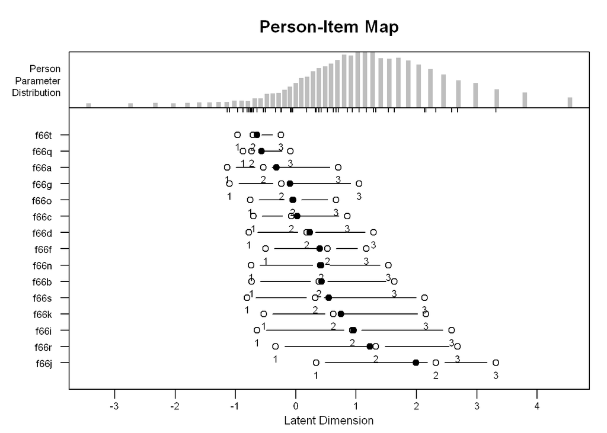

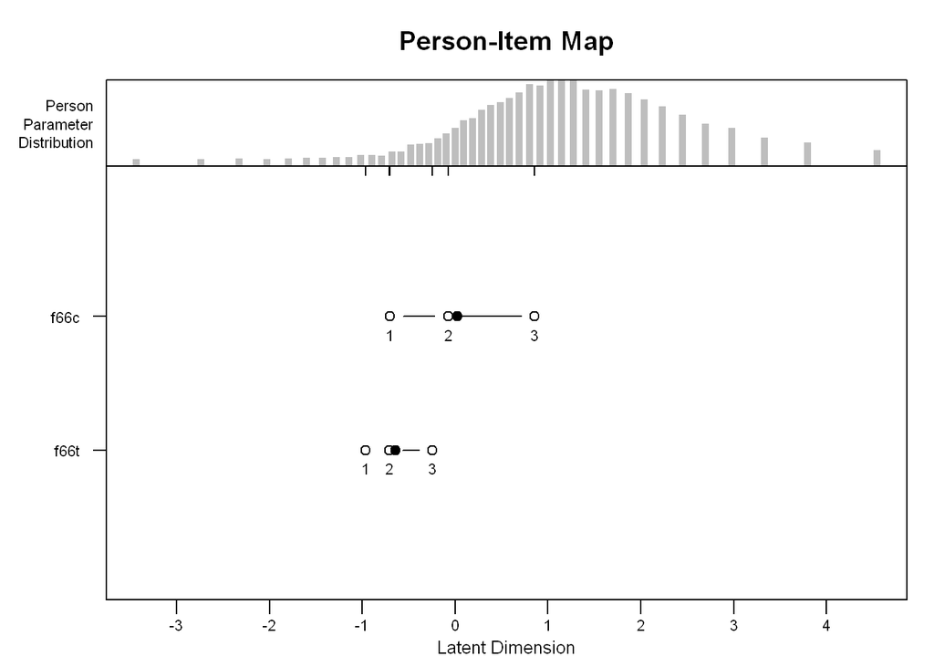

Vi ser att f66c har ett bredare omfång än f66t, så den senare tas bort.

Med ytterligare 2 items borttagna har vi nu eigenvalues på 1.754, 1.405, 1.377, 1.227, 1.062.

Vi tittar på residualkorrelationerna igen:

|  | f66a | f66c | f66d | f66f | f66g | f66i | f66j | f66k | f66n | f66o | f66q | f66r | f66s |
| --- | --- | --- | --- | --- | --- | --- | --- | --- | --- | --- | --- | --- | --- |
| f66a | NA | NA | NA | NA | NA | NA | NA | NA | NA | NA | NA | NA | NA |
| f66c | 0.05 | NA | NA | NA | NA | NA | NA | NA | NA | NA | NA | NA | NA |
| f66d | 0.00 | -0.05 | NA | NA | NA | NA | NA | NA | NA | NA | NA | NA | NA |
| f66f | -0.17 | -0.19 | -0.16 | NA | NA | NA | NA | NA | NA | NA | NA | NA | NA |
| f66g | 0.01 | -0.11 | 0.00 | 0.13 | NA | NA | NA | NA | NA | NA | NA | NA | NA |
| f66i | -0.10 | -0.07 | -0.22 | -0.03 | -0.11 | NA | NA | NA | NA | NA | NA | NA | NA |
| f66j | -0.15 | -0.14 | -0.16 | 0.03 | -0.08 | 0.12 | NA | NA | NA | NA | NA | NA | NA |
| f66k | -0.08 | -0.09 | 0.03 | -0.15 | -0.10 | -0.06 | 0.01 | NA | NA | NA | NA | NA | NA |
| f66n | -0.11 | -0.10 | -0.13 | 0.07 | 0.11 | -0.06 | 0.02 | -0.13 | NA | NA | NA | NA | NA |
| f66o | 0.16 | 0.02 | -0.04 | -0.21 | -0.07 | -0.13 | -0.12 | 0.00 | -0.02 | NA | NA | NA | NA |
| f66q | -0.05 | -0.04 | 0.02 | -0.13 | 0.00 | -0.16 | -0.18 | -0.07 | -0.08 | -0.01 | NA | NA | NA |
| f66r | -0.12 | -0.11 | -0.11 | -0.11 | -0.12 | -0.01 | -0.05 | -0.20 | 0.00 | -0.11 | -0.08 | NA | NA |
| f66s | -0.04 | -0.07 | 0.03 | -0.14 | -0.14 | -0.18 | -0.18 | -0.18 | -0.18 | -0.10 | 0.00 | 0.04 | NA |

|  | f66a | f66c | f66d | f66f | f66g | f66i | f66j | f66k | f66n | f66o | f66q | f66r | f66s |
| --- | --- | --- | --- | --- | --- | --- | --- | --- | --- | --- | --- | --- | --- |
| f66a | NA | NA | NA | NA | NA | NA | NA | NA | NA | NA | NA | NA | NA |
| f66c | 0.05 | NA | NA | NA | NA | NA | NA | NA | NA | NA | NA | NA | NA |
| f66d | 0.00 | -0.05 | NA | NA | NA | NA | NA | NA | NA | NA | NA | NA | NA |
| f66f | -0.17 | -0.19 | -0.16 | NA | NA | NA | NA | NA | NA | NA | NA | NA | NA |
| f66g | 0.01 | -0.11 | 0.00 | 0.13 | NA | NA | NA | NA | NA | NA | NA | NA | NA |
| f66i | -0.10 | -0.07 | -0.22 | -0.03 | -0.11 | NA | NA | NA | NA | NA | NA | NA | NA |
| f66j | -0.15 | -0.14 | -0.16 | 0.03 | -0.08 | 0.12 | NA | NA | NA | NA | NA | NA | NA |
| f66k | -0.08 | -0.09 | 0.03 | -0.15 | -0.10 | -0.06 | 0.01 | NA | NA | NA | NA | NA | NA |
| f66n | -0.11 | -0.10 | -0.13 | 0.07 | 0.11 | -0.06 | 0.02 | -0.13 | NA | NA | NA | NA | NA |
| f66o | 0.16 | 0.02 | -0.04 | -0.21 | -0.07 | -0.13 | -0.12 | 0.00 | -0.02 | NA | NA | NA | NA |
| f66q | -0.05 | -0.04 | 0.02 | -0.13 | 0.00 | -0.16 | -0.18 | -0.07 | -0.08 | -0.01 | NA | NA | NA |
| f66r | -0.12 | -0.11 | -0.11 | -0.11 | -0.12 | -0.01 | -0.05 | -0.20 | 0.00 | -0.11 | -0.08 | NA | NA |
| f66s | -0.04 | -0.07 | 0.03 | -0.14 | -0.14 | -0.18 | -0.18 | -0.18 | -0.18 | -0.10 | 0.00 | 0.04 | NA |

Titta snabbt på dessa items i en egen dimensionalitetsanalys?

# 3 Svarskategorier

En samlad bild av svarskategorierna ges nedan.

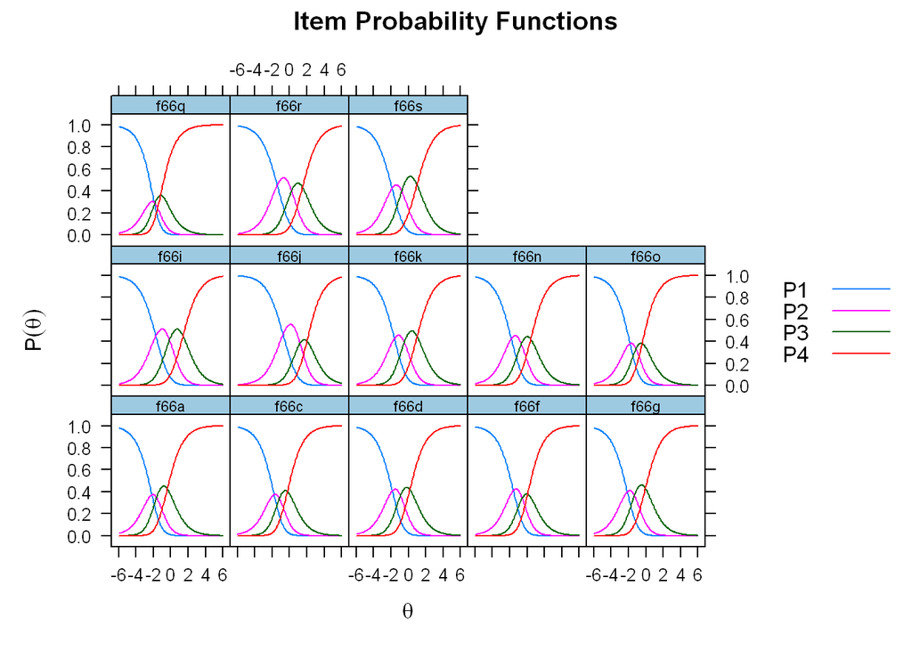

Svarskategorierna verkar fungera bra, inga fullständiga överlappningar. Ett möjligt undantag är f66q, som vi får titta närmare på.

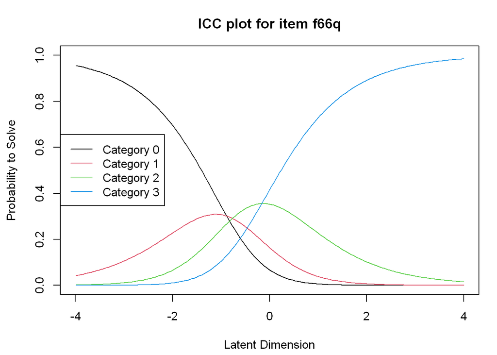

# 4 Targeting

Först tittar vi på items enskilda kurvor och sammanslagna.

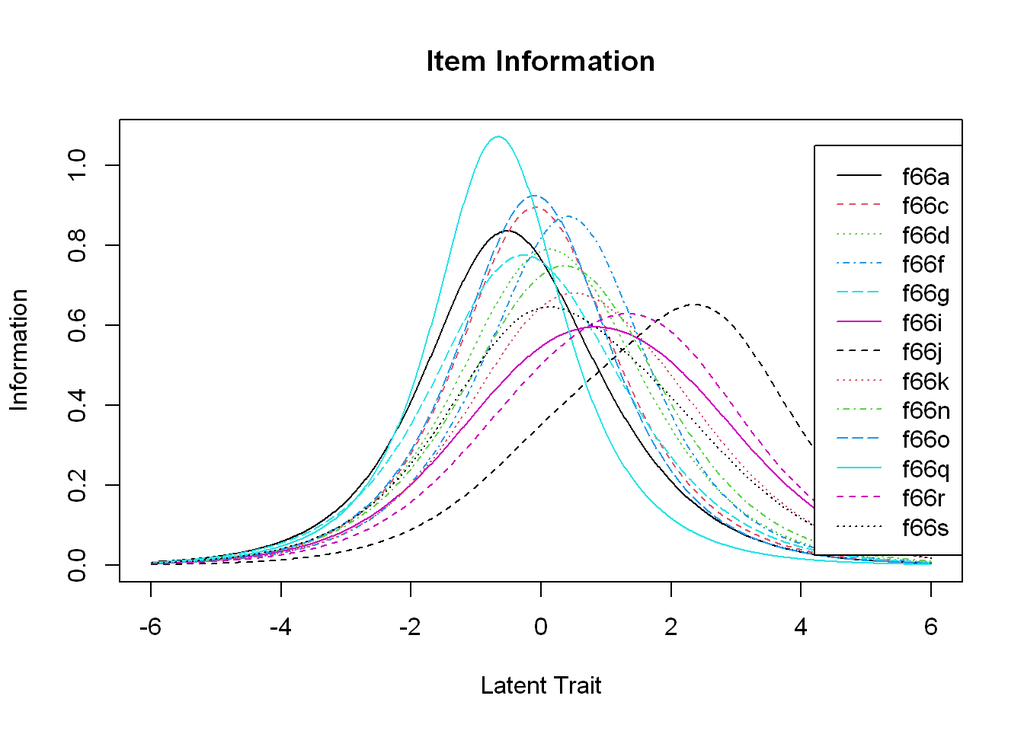

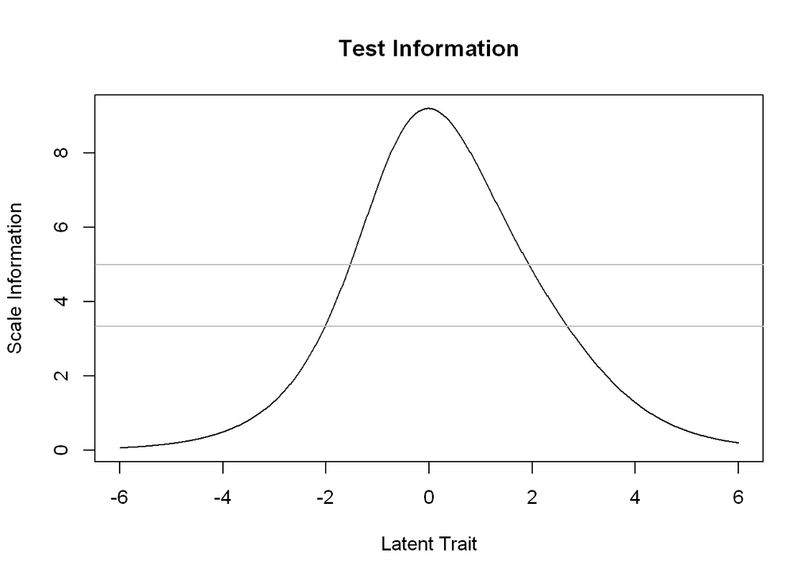

De horisontella grå linjerna i figuren “Test information” visar var gränsvärden går för reliabilitet 0.7 (nedre) respektive 0.8.

Sedan tar vi fram separata histogram för personernas övergripande förmåga samt item-trösklarna. Båda visas på samma skala, för att vara jämförbara. Trösklarna ger oss information om huruvida en person passerat tröskeln eller inte, och är grunden för att kunna ta fram en skattning av övergripande förmåga.

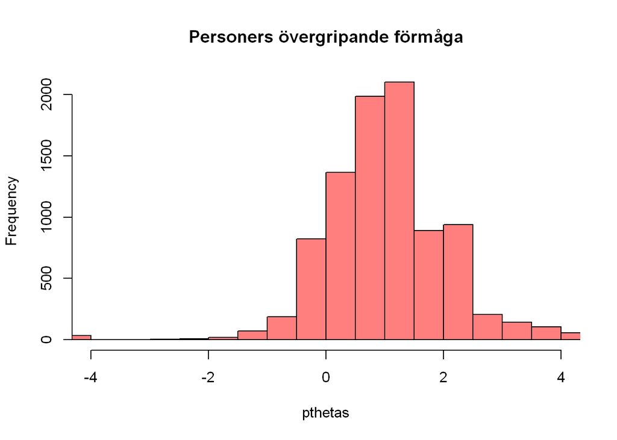

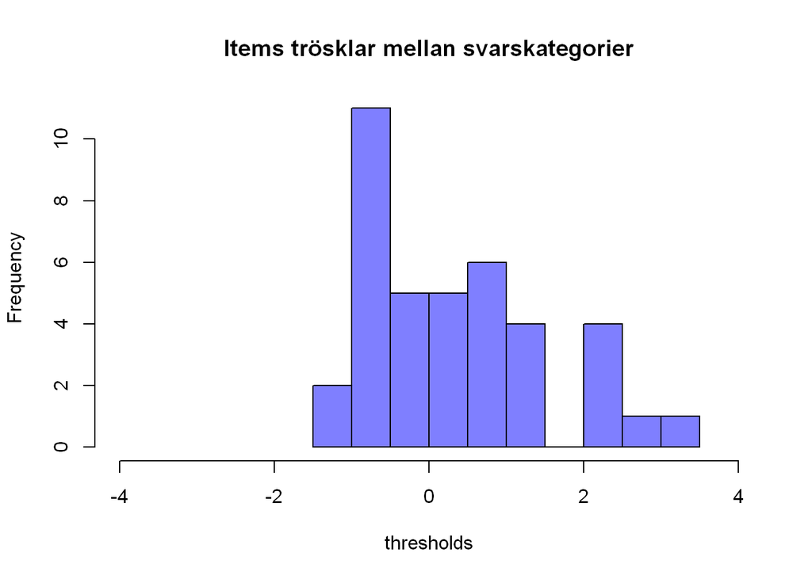

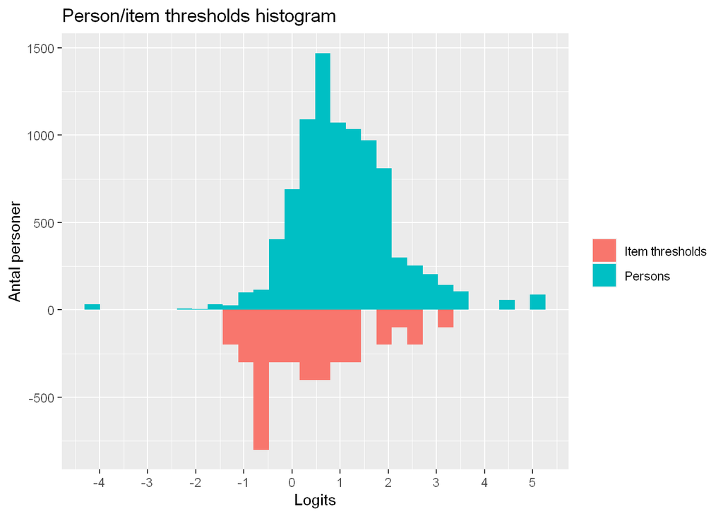

## 4.1 Invarians och DIF

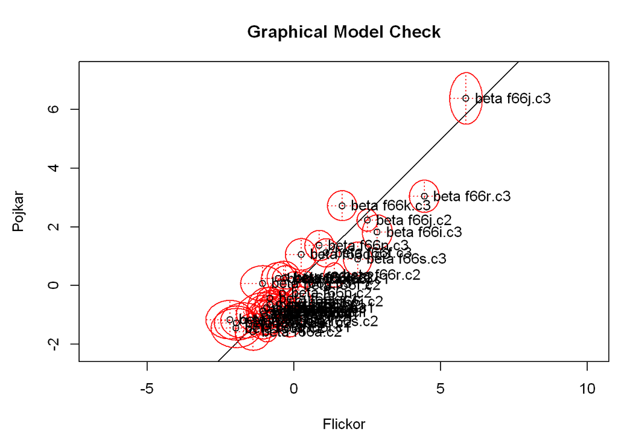